# Midterm Project:Group 04

Shakib-241001661,Shudeshna-241000261,Mithun-241002261,Pradipto-241002161,Mufrad-241001461,Shahriar Islam- 241000461

2024-06-02

# 1 BACKGROUND

A health insurance company’s financial success relies on generating more revenue than it incurs cost on the healthcare of its policyholders. However, forecasting medical expenses is challenging due to the unpredictability of costs associated with rare conditions. This project aims to precisely predict insurance costs by analyzing individuals’ data, such as age, Body Mass Index, smoking habits, and other factors. Furthermore, we will identify the key variable that has the most significant impact on insurance costs. These predic tions can be utilized to develop actuarial tables, enabling the adjustment of yea rly premiums based on anticipated treatment expenses. This essentially constitutes a regression problem.

# 2 DATASET

In this project, the dataset is already separated randomly into train and test dataset. The features in the dataset are: **important**:

1. `age: age of primary beneficiary.`
2. `sex: insurance contractor gender, female, male.`
3. `bmi: Body Mass Index, providing an understanding of body, weights that are relatively high or low relative to height, objective index of body weight (kg/m2) using the ratio of height to weight, ideally 18.5 to 24.9.`
4. `children: number of children covered by health insurance / number of dependents.`
5. `smoker: smoking or not.`
6. `region: the beneficiary’s residential area in the US, northeast, southeast, southwest,northwest.`
7. `charges: individual medical costs billed by health insurance.`

** Since we are predicting insurance costs, charges will be our target feature.**

```r
library(dplyr)          # data wrangling
```

```r
library(ggplot2)        # graphing
library(caret)          # machine learning functions
#install.packages("MLmetrics")
library(MLmetrics)      # machine learning metrics
library(car)            # VIF calculation
#install.packages("lmtest")
library(lmtest)         # linear regression model testing
#install.packages("GGally")
library(GGally)         # correlation plot
#load data set
train <-   read.csv("https://raw.githubusercontent.com/shakibed/CBD501_Mid_Project_Group_04/main/train.csv", stringsAsFactors = TRUE)
test <- read.csv("https://raw.githubusercontent.com/shakibed/CBD501_Mid_Project_Group_04/main/test.csv", stringsAsFactors=TRUE)
```

# 3 EXPECTED TASKS

## 3.1 Data Preparation [Training Dataset] [Marks: 05]

1.`Check if each feature is already in correct data type. If not set the correct data type.`

```r
#1.Check if each feature is already in correct data type. If not set the correct data type.
glimpse(train)
```

```
## Rows: 1,070
## Columns: 7
## $ age      <int> 37, 18, 23, 32, 58, 25, 36, 34, 53, 45, 20, 60, 58, 34, 60, 1…
## $ sex      <fct> male, male, female, male, female, female, male, female, male,…
## $ bmi      <dbl> 34.100, 34.430, 36.670, 35.200, 32.395, 26.790, 35.200, 33.25…
## $ children <int> 4, 0, 2, 2, 1, 2, 1, 1, 0, 5, 1, 1, 0, 0, 0, 0, 1, 3, 5, 1, 1…
## $ smoker   <fct> yes, no, yes, no, no, no, yes, no, no, no, no, no, no, no, no…
## $ region   <fct> southwest, southeast, northeast, southwest, northeast, northw…
## $ charges  <dbl> 40182.246, 1137.470, 38511.628, 4670.640, 13019.161, 4189.113…
```

**we can see above that each feature is already in its correct type**

2.`Check if there are any duplicated observations on train dataset. If there’s then drop the row.`

```r
train[duplicated(train), ]
```

```
##     age  sex   bmi children smoker    region  charges
## 268  19 male 30.59        0     no northwest 1639.563
```

```r
#There is one duplication, we are dropping the duplicate row.
train <- train %>% distinct()
```

** There is one duplication, we have dropped the duplicate row.**

3.`Inspect for missing value. If there’s any missing value, please perform appropriate treatment.`

```r
#Inspect for missing value in train data set
colSums(is.na(train))
```

```
##      age      sex      bmi children   smoker   region  charges
##        0        0        0        0        0        0        0
```

```r
#Inspect for missing value in test data set
colSums(is.na(test))
```

```
##      age      sex      bmi children   smoker   region  charges
##        0        0        0        0        0        0        0
```

**No missing values found**

## 3.2 Exploratory Data Analysis (EDA) [Training Dataset] [Marks: 08]

1.`Show the descriptive statistics of training dataset. Explain the numeric & categorical features.`

```r
summary(train)
```

```
##       age            sex           bmi           children    smoker
##  Min.   :18.00   female:543   Min.   :15.96   Min.   :0.00   no :850
##  1st Qu.:26.00   male  :526   1st Qu.:26.32   1st Qu.:0.00   yes:219
##  Median :39.00                Median :30.40   Median :1.00
##  Mean   :39.11                Mean   :30.73   Mean   :1.08
##  3rd Qu.:51.00                3rd Qu.:34.80   3rd Qu.:2.00
##  Max.   :64.00                Max.   :53.13   Max.   :5.00
##        region       charges
##  northeast:249   Min.   : 1122
##  northwest:253   1st Qu.: 4747
##  southeast:294   Median : 9447
##  southwest:273   Mean   :13212
##                  3rd Qu.:16587
##                  Max.   :63770
```

2.`Show the distribution of ‘Charges’ through appropriate plot. Explain the plot.`

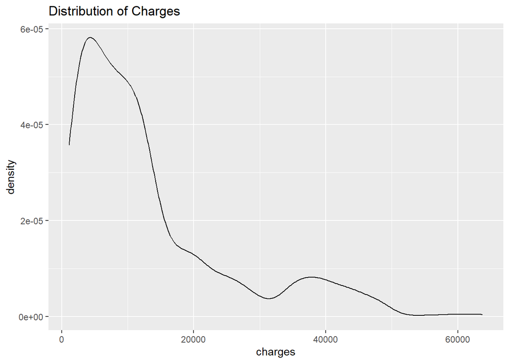

```r
ggplot(data = train, aes(x = charges)) +
  geom_density(alpha = 0.5) +
  ggtitle("Distribution of Charges")
```

3.`Create below boxplots. And explain if there’s any pattern.`

```
i.`Boxplot of Medical Charges as per sex.`
ii.`Boxplot of Medical Charges as per region.`
iii.`Boxplot of Medical Charges as per children.`
iv.`Boxplot of Medical Charges as per smoker.`
```

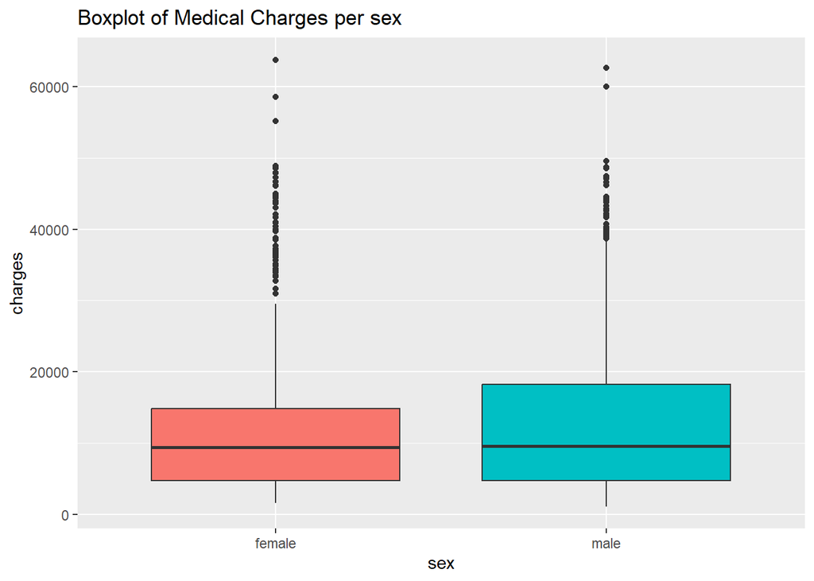

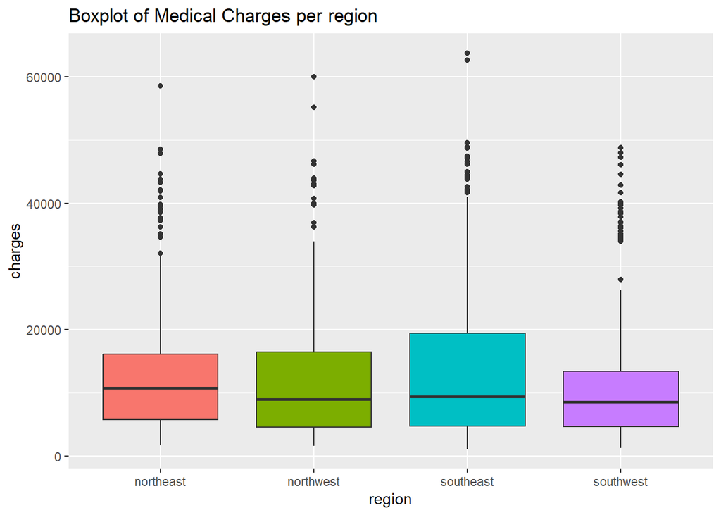

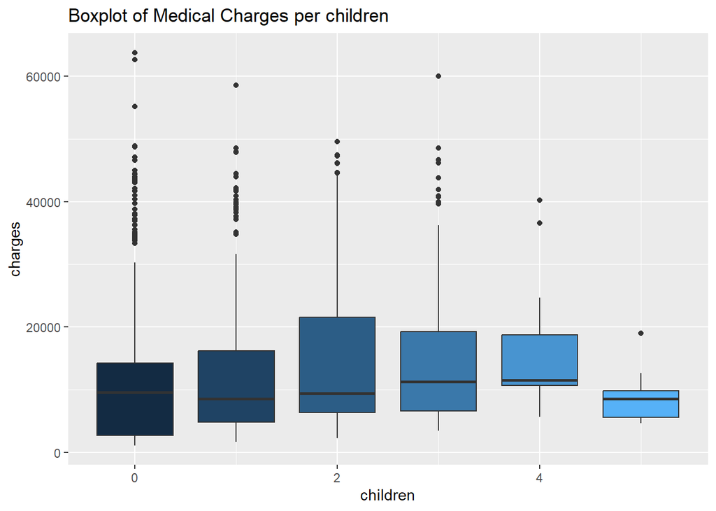

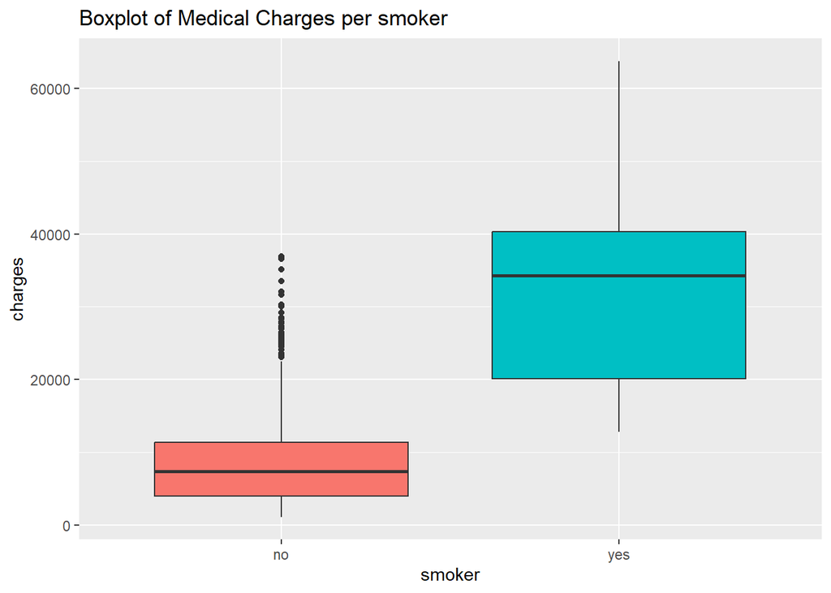

```r
for (col in c('sex', 'region', 'children', 'smoker')) {
  plot <- ggplot(data = train,
                 aes_string(x = col, y = 'charges', group = col, fill = col)) +
            geom_boxplot(show.legend = FALSE) +
            ggtitle(glue::glue("Boxplot of Medical Charges per {col}"))
  print(plot)
}
```

4.`Create a distribution of ‘charges’ categorizing it into smoker & non-smoker. Use two separate colors for each category.`

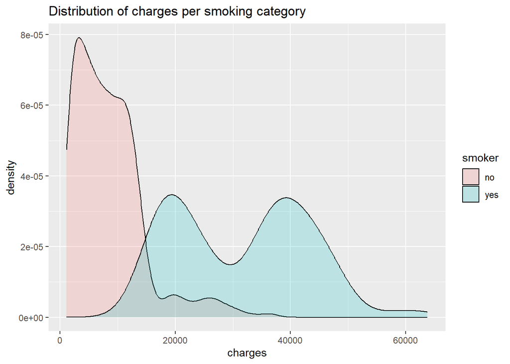

```r
ggplot(data=train, aes(x=charges,fill=smoker))+
  geom_density(alpha=0.2)+
  ggtitle("Distribution of charges per smoking category")
```

**The distribution is right-skewed with a long tail extending to the right.**

5.`Analyze the medical charges by age, bmi and children according to the smoker factor. [Hints: You can create a ‘for’ loop to create the plots of each feature. In each plot X = age/bmi/children; Y = charges, group = smoker, fill = smoker.]`

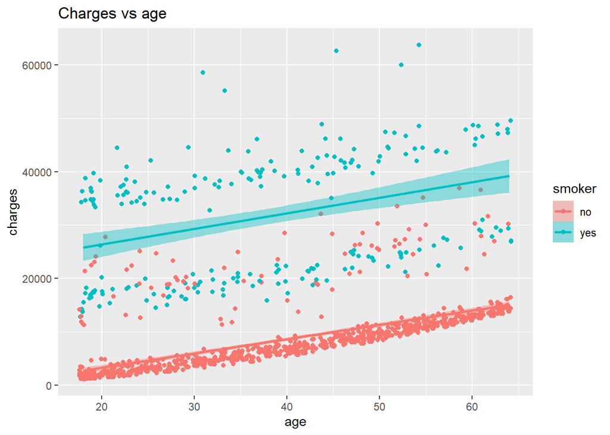

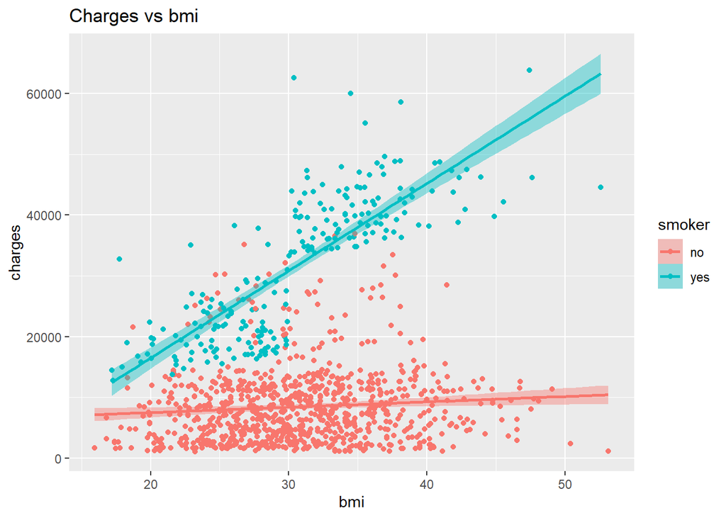

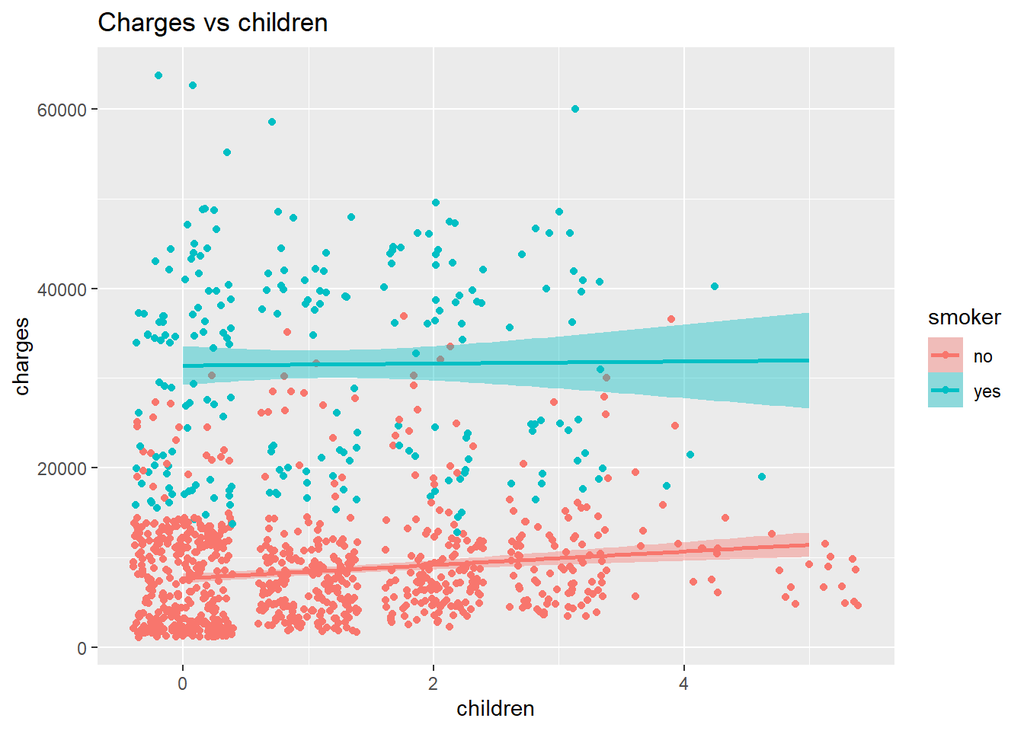

```r
for (feat in c('age', 'bmi', 'children')) {
  plot <- ggplot(data = train, aes_string(x = feat, y = 'charges', group = 'smoker', fill = 'smoker', col = 'smoker')) +
    geom_jitter() +
    geom_smooth(method = 'lm') +
    ggtitle(glue::glue("Charges vs {feat}"))
  print(plot)
}
```

6.`Create a correlation heatmap among features. Explain the plot.`

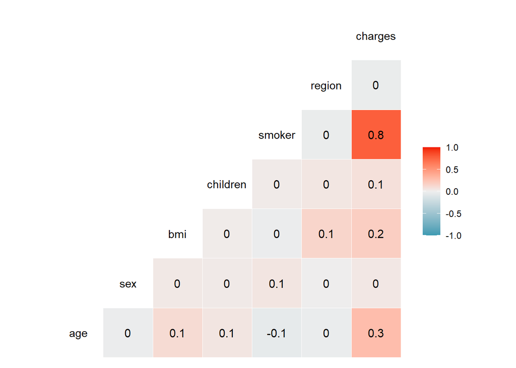

```r
ggcorr(train %>% mutate_if(is.factor, as.numeric), label = TRUE)
```

## 3.3 Linear Regression Analysis [Marks: 12]

Step 01: `Exploring the models. [Marks: 02]`

```r
temp <- lm(charges ~ ., data = train)
step(temp)
```

```
## Start:  AIC=18667.88
## charges ~ age + sex + bmi + children + smoker + region
##
##            Df  Sum of Sq        RSS   AIC
## - region    3 1.3678e+08 4.0476e+10 18666
## - sex       1 4.3071e+04 4.0339e+10 18666
## <none>                   4.0339e+10 18668
## - children  1 2.9468e+08 4.0633e+10 18674
## - bmi       1 4.1333e+09 4.4472e+10 18770
## - age       1 1.3330e+10 5.3669e+10 18971
## - smoker    1 9.5616e+10 1.3596e+11 19965
##
## Step:  AIC=18665.5
## charges ~ age + sex + bmi + children + smoker
##
##            Df  Sum of Sq        RSS   AIC
## - sex       1 1.2092e+05 4.0476e+10 18664
## <none>                   4.0476e+10 18666
## - children  1 2.8813e+08 4.0764e+10 18671
## - bmi       1 4.1471e+09 4.4623e+10 18768
## - age       1 1.3501e+10 5.3976e+10 18971
## - smoker    1 9.6274e+10 1.3675e+11 19965
##
## Step:  AIC=18663.5
## charges ~ age + bmi + children + smoker
##
##            Df  Sum of Sq        RSS   AIC
## <none>                   4.0476e+10 18664
## - children  1 2.8803e+08 4.0764e+10 18669
## - bmi       1 4.1517e+09 4.4627e+10 18766
## - age       1 1.3509e+10 5.3984e+10 18969
## - smoker    1 9.6514e+10 1.3699e+11 19965
```

```
##
## Call:
## lm(formula = charges ~ age + bmi + children + smoker, data = train)
##
## Coefficients:
## (Intercept)          age          bmi     children    smokeryes
##    -11905.1        254.9        320.6        429.9      23586.1
```

Step 02: `Prediction. [Marks: 02]`

```r
#Use the model selected in Step 02 and predict using the Training dataset.
lm_all <- lm(formula = charges ~ age + bmi + children + smoker, data = train)
y_pred <- predict(lm_all, test)
```

Step 03: `Evaluating the model performance. [Marks: 03]`

```r
mae <- MAE(y_pred, test$charges)
rmse <- RMSE(y_pred, test$charges)
y_pred[y_pred <=0]
```

```
##       149
## -87.05982
```

```r
rmsle <- RMSLE(y_pred[-149], test$charges[-149])
lin_reg <- cbind("MAE" = mae, "RMSE" = rmse, "RMSLE" = rmsle)
lin_reg
```

```
##           MAE     RMSE     RMSLE
## [1,] 3941.464 5672.102 0.5455373
```

**We found the errors mentioned above. For MAE and RMSE, we can understand them like this: the model guesses charges with an average difference of $3,941 and $5,672 from the actual values, respectively.**

Step 04: `Evaluate the model. [Marks: 02]`

```r
summary(lm_all)
```

```
##
## Call:
## lm(formula = charges ~ age + bmi + children + smoker, data = train)
##
## Residuals:
##    Min     1Q Median     3Q    Max
## -11734  -2983  -1004   1356  29708
##
## Coefficients:
##              Estimate Std. Error t value Pr(>|t|)
## (Intercept) -11905.11    1060.63 -11.225  < 2e-16 ***
## age            254.87      13.52  18.844  < 2e-16 ***
## bmi            320.64      30.69  10.447  < 2e-16 ***
## children       429.86     156.22   2.752  0.00603 **
## smokeryes    23586.13     468.26  50.370  < 2e-16 ***
## ---
## Signif. codes:  0 '***' 0.001 '**' 0.01 '*' 0.05 '.' 0.1 ' ' 1
##
## Residual standard error: 6168 on 1064 degrees of freedom
## Multiple R-squared:  0.7359, Adjusted R-squared:  0.7349
## F-statistic: 741.3 on 4 and 1064 DF,  p-value: < 2.2e-16
```

**We have four important features. Among them, “smoker” stands out with the largest effect on the charges. A change in being a smoker results in a much bigger change in charges compared to changes in other features, assuming all other factors remain constant. For example, if all other factors remain the same, a non-smoker would typically have $23,586 less in charges compared to a smoker.**

**Additionally, this model has an adjusted R-squared value of 0.7349. This means that the features in the model explain around 73% of the total variation in charges.**

Step 05: `Checking the validity of linear model assumptions. [Marks: 03]`

```
  i.`Testing Linearity: `
```

```r
# Calculate Pearson correlation coefficients
correlations <- cor(train[c("age", "bmi", "children", "charges")])

# Print the correlation matrix
print(correlations)
```

```
##                 age        bmi   children    charges
## age      1.00000000 0.11226677 0.05495668 0.27943872
## bmi      0.11226677 1.00000000 0.02018246 0.18447676
## children 0.05495668 0.02018246 1.00000000 0.08362433
## charges  0.27943872 0.18447676 0.08362433 1.00000000
```

```r
# Test the significance of the correlation coefficients
cor.test.age <- cor.test(train$age, train$charges)
cor.test.bmi <- cor.test(train$bmi, train$charges)
cor.test.children <- cor.test(train$children, train$charges)

# Print the results
cor.test.age
```

```
##
##  Pearson's product-moment correlation
##
## data:  train$age and train$charges
## t = 9.5066, df = 1067, p-value < 2.2e-16
## alternative hypothesis: true correlation is not equal to 0
## 95 percent confidence interval:
##  0.2232205 0.3338041
## sample estimates:
##       cor
## 0.2794387
```

```r
cor.test.bmi
```

```
##
##  Pearson's product-moment correlation
##
## data:  train$bmi and train$charges
## t = 6.1312, df = 1067, p-value = 1.226e-09
## alternative hypothesis: true correlation is not equal to 0
## 95 percent confidence interval:
##  0.1259113 0.2417608
## sample estimates:
##       cor
## 0.1844768
```

```r
cor.test.children
```

```
##
##  Pearson's product-moment correlation
##
## data:  train$children and train$charges
## t = 2.7412, df = 1067, p-value = 0.006224
## alternative hypothesis: true correlation is not equal to 0
## 95 percent confidence interval:
##  0.02378543 0.14286616
## sample estimates:
##        cor
## 0.08362433
```

**Age and BMI both show significant linear relationships with charges, though age has a stronger relationship than BMI. The number of children has a very weak but statistically significant relationship with charges.**

```
  ii.`Residual Normality `
```

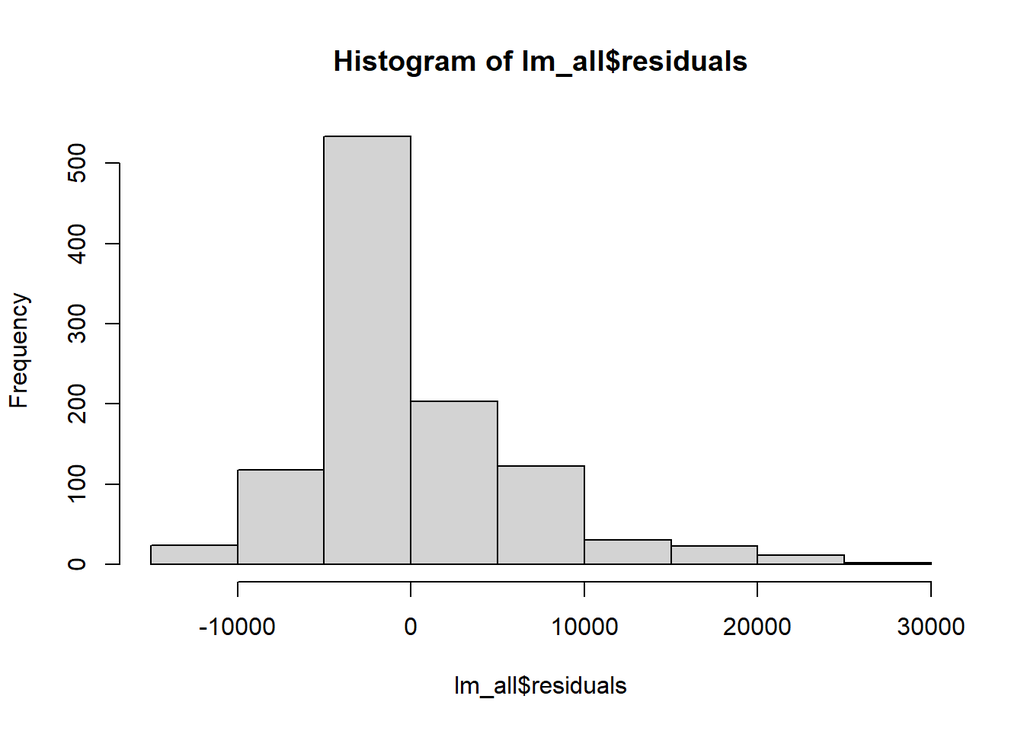

```r
hist(lm_all$residuals)
```

** from Histogram we observed residuals are not normally distributed.**

Another way is to use Shapiro-Wilk test to our residual.

H0: `Residuals are normally distributed` H1: `Residuals are not normally distributed`

```r
shapiro.test(lm_all$residuals)
```

```
##
##  Shapiro-Wilk normality test
##
## data:  lm_all$residuals
## W = 0.89481, p-value < 2.2e-16
```

**Since p-value is below alpha (0.05), reject H0. Hence, residuals are not normally distributed.**

```
  iii.`Checking Homoscedasticity`
```

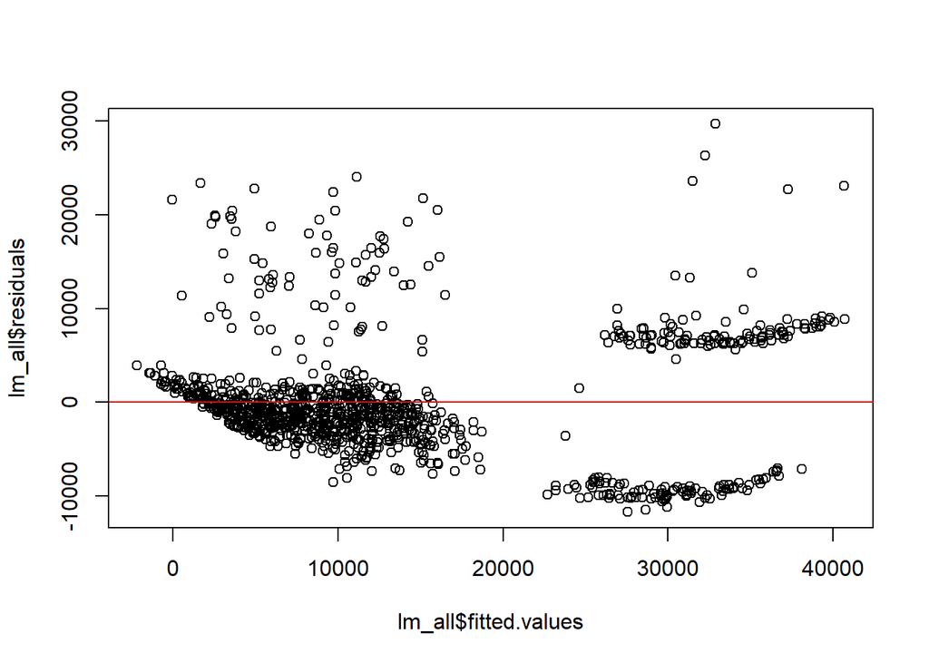

```r
plot(lm_all$fitted.values, lm_all$residuals)
abline(h=0, col = "red")
```

**In a Linear Regression model, since the variance of its error is showing unequal variation across the target variable range, it shows that heteroscedasticity is present. We can see this visually by plotting fitted values vs residuals**

Another way is to use Breusch-Pagan hypothesis.

H0: `Homoscedasticity` H1: `Heteroscedasticity`

```r
bptest(lm_all)
```

```
##
##  studentized Breusch-Pagan test
##
## data:  lm_all
## BP = 89.206, df = 4, p-value < 2.2e-16
```

**Since p-value is lower than alpha (0.05), reject H0. This means the residuals has Heteroscedasticity.**

iv.`Assessing Multicollinearity`

```r
# Calculate VIF
library(car)
vif(lm_all)
```

```
##      age      bmi children   smoker
## 1.018303 1.013178 1.004060 1.003712
```

**No multicollinearity found in Linear Regression model**